# COVID-19 Case Study

# Background

The outbreak of the novel Corona virus disease 2019 (COVID-19) was declared a public health emergency of international concern by the World Health Organization (WHO) on January 30, 2020. Upwards of [112 million cases have been confirmed worldwide, with nearly 2.5 million associated deaths](https://covid19.who.int/). Within the US alone, there have been [over 500,000 deaths and upwards of 28 million cases reported](https://covid.cdc.gov/covid-data-tracker/#trends_dailytrendscases). Governments around the world have implemented and suggested a number of policies to lessen the spread of the pandemic, including mask-wearing requirements, travel restrictions, business and school closures, and even stay-at-home orders. The global pandemic has impacted the lives of individuals in countless ways, and though many countries have begun vaccinating individuals, the long-term impact of the virus remains unclear.

The impact of COVID-19 on a given segment of the population appears to vary drastically based on the socioeconomic characteristics of the segment. In particular, differing rates of infection and fatalities have been reported among different [racial groups](https://www.cdc.gov/coronavirus/2019-ncov/covid-data/investigations-discovery/hospitalization-death-by-race-ethnicity.html), [age groups](https://www.cdc.gov/coronavirus/2019-ncov/covid-data/investigations-discovery/hospitalization-death-by-age.html), and [socioeconomic groups](https://www.ncbi.nlm.nih.gov/pmc/articles/PMC7221360/). One of the most important metrics for determining the impact of the pandemic is the death rate, which is the proportion of people within the total population that die due to the the disease.

## Data Summary

The data comes from several different sources:

1. [County-level infection and fatality data](https://github.com/nytimes/covid-19-data) - This dataset gives daily cumulative numbers on infection and fatality for each county.
   - [NYC data](https://github.com/nychealth/coronavirus-data)
2. [County-level socioeconomic data](https://www.ers.usda.gov/data-products/atlas-of-rural-and-small-town-america/download-the-data/) - The following are the four relevant datasets from this site.
   1. Income - Poverty level and household income.
   2. Jobs - Employment type, rate, and change.
   3. People - Population size, density, education level, race, age, household size, and migration rates.
   4. County Classifications - Type of county (rural or urban on a rural-urban continuum scale).

**There are two main goals for this study.**

1. Number of deaths vary drastically across State. We want to find out how State relate to the death rate.
2. There have been studies on COVID racial disparities. Looking for evidence in our data to show that the proportion of race relates to the death at county level.

```r
# This is how we created the covid_county_midterm_spring_2022.csv
# DONOT RUN this chunk

# county-level socialeconomic information
county_data <- fread("covid_county(1).csv")
# county-level COVID case and death
covid_rate <- fread("covid_rates(1).csv")

# northeast regions
northeast <- c("CT", "DC", "ME", "MA", "NH",
               "NJ", "NY", "PA", "MD", "RI", "VT")

covid_county_temp <- covid_rate %>%
  filter(date == "2020-09-01") %>%
  mutate(log_death_rate = log( (cum_deaths+1)/(TotalPopEst2019+2) )) %>%
  select(FIPS, cum_deaths, log_death_rate)

# join with county-level demographic data
covid_county_temp <-
  left_join(covid_county_temp,
            county_data,
            by = "FIPS") %>%
  filter(State %in% northeast) %>%

  drop_na()

# take a subset of the demographic info
covid_county_sub <- covid_county_temp %>%
  select(log_death_rate, State, Deep_Pov_All, PovertyAllAgesPct, PerCapitaInc, UnempRate2019, PctEmpFIRE, PctEmpConstruction, PctEmpTrans, PctEmpMining, PctEmpTrade, PctEmpInformation, PctEmpAgriculture, PctEmpManufacturing, PctEmpServices, PopDensity2010, OwnHomePct, Age65AndOlderPct2010, TotalPop25Plus, Under18Pct2010, Ed2HSDiplomaOnlyPct, Ed3SomeCollegePct, Ed4AssocDegreePct, Ed5CollegePlusPct, ForeignBornPct, Net_International_Migration_Rate_2010_2019, NetMigrationRate1019, NaturalChangeRate1019, TotalPopEst2019, WhiteNonHispanicPct2010, Type_2015_Update, RuralUrbanContinuumCode2013, UrbanInfluenceCode2013, Perpov_1980_0711, HiCreativeClass2000, HiAmenity, Retirement_Destination_2015_Update)

# output
write.csv(covid_county_sub, "C:\\Users\\phili\\Desktop\\Projects\\Applied-Machine-Learning\\Covid\\covid_2022.csv")
```

```r
covid_county <- read.csv("covid_2022.csv") # let's not use fread to avoid unexpected problems.
```

There are 37 variables in total, and there are 242 counties in total. There are no missing values as indicated by the summary below.

```r
summary(covid_county)
```

```
##        X         log_death_rate      State            Deep_Pov_All
##  Min.   :  1.0   Min.   :-11.53   Length:242         Min.   : 2.08
##  1st Qu.: 61.2   1st Qu.: -9.35   Class :character   1st Qu.: 3.96
##  Median :121.5   Median : -8.17   Mode  :character   Median : 5.04
##  Mean   :121.5   Mean   : -8.26                      Mean   : 5.32
##  3rd Qu.:181.8   3rd Qu.: -7.16                      3rd Qu.: 6.41
##  Max.   :242.0   Max.   : -5.89                      Max.   :12.60
##  PovertyAllAgesPct  PerCapitaInc   UnempRate2019    PctEmpFIRE
##  Min.   : 4.4      Min.   :15360   Min.   :1.80   Min.   : 1.81
##  1st Qu.: 9.0      1st Qu.:26882   1st Qu.:3.22   1st Qu.: 3.92
##  Median :11.4      Median :31218   Median :3.90   Median : 5.02
##  Mean   :11.6      Mean   :33082   Mean   :4.02   Mean   : 5.54
##  3rd Qu.:14.1      3rd Qu.:37793   3rd Qu.:4.70   3rd Qu.: 6.74
##  Max.   :27.3      Max.   :72832   Max.   :7.40   Max.   :16.37
##  PctEmpConstruction  PctEmpTrans     PctEmpMining   PctEmpTrade
##  Min.   : 1.97      Min.   : 1.92   Min.   :0.00   Min.   : 5.19
##  1st Qu.: 5.62      1st Qu.: 3.69   1st Qu.:0.05   1st Qu.:12.73
##  Median : 6.69      Median : 4.51   Median :0.11   Median :13.93
##  Mean   : 6.93      Mean   : 4.84   Mean   :0.41   Mean   :13.77
##  3rd Qu.: 7.77      3rd Qu.: 5.88   3rd Qu.:0.37   3rd Qu.:15.07
##  Max.   :19.42      Max.   :11.36   Max.   :9.78   Max.   :19.00
##  PctEmpInformation PctEmpAgriculture PctEmpManufacturing PctEmpServices
##  Min.   :0.51      Min.   : 0.05     Min.   : 1.3        Min.   :31.7
##  1st Qu.:1.26      1st Qu.: 0.43     1st Qu.: 7.1        1st Qu.:45.8
##  Median :1.62      Median : 1.07     Median :10.5        Median :48.8
##  Mean   :1.74      Mean   : 1.70     Mean   :10.7        Mean   :49.0
##  3rd Qu.:2.08      3rd Qu.: 2.55     3rd Qu.:13.7        3rd Qu.:52.1
##  Max.   :6.29      Max.   :12.98     Max.   :40.1        Max.   :69.3
##  PopDensity2010    OwnHomePct   Age65AndOlderPct2010 TotalPop25Plus
##  Min.   :    3   Min.   :19.6   Min.   : 9.44        Min.   :   3536
##  1st Qu.:   73   1st Qu.:67.7   1st Qu.:13.54        1st Qu.:  34101
##  Median :  184   Median :72.2   Median :15.26        Median :  71667
##  Mean   : 1371   Mean   :70.6   Mean   :15.42        Mean   : 180081
##  3rd Qu.:  524   3rd Qu.:75.8   3rd Qu.:17.02        3rd Qu.: 204498
##  Max.   :69468   Max.   :85.9   Max.   :24.96        Max.   :1777281
##  Under18Pct2010 Ed2HSDiplomaOnlyPct Ed3SomeCollegePct Ed4AssocDegreePct
##  Min.   :12.4   Min.   :12.4        Min.   : 9.77     Min.   : 3.01
##  1st Qu.:20.2   1st Qu.:28.0        1st Qu.:15.80     1st Qu.: 7.72
##  Median :21.6   Median :32.9        Median :17.35     Median : 8.99
##  Mean   :21.6   Mean   :33.7        Mean   :17.44     Mean   : 9.18
```

[output cut: 22 more lines]

```
##  Max.   :98.1            Max.   :5        Max.   :9.00
##  UrbanInfluenceCode2013 Perpov_1980_0711 HiCreativeClass2000   HiAmenity
##  Min.   : 1.00          Min.   :0.000    Min.   :0.000       Min.   :0.000
##  1st Qu.: 1.00          1st Qu.:0.000    1st Qu.:0.000       1st Qu.:0.000
##  Median : 2.00          Median :0.000    Median :1.000       Median :0.000
##  Mean   : 3.21          Mean   :0.017    Mean   :0.574       Mean   :0.112
##  3rd Qu.: 5.00          3rd Qu.:0.000    3rd Qu.:1.000       3rd Qu.:0.000
##  Max.   :11.00          Max.   :1.000    Max.   :1.000       Max.   :1.000
##  Retirement_Destination_2015_Update
##  Min.   :0.00
##  1st Qu.:0.00
##  Median :0.00
##  Mean   :0.05
##  3rd Qu.:0.00
##  Max.   :1.00
```

# 2. EDA

During the course of pandemic, policies are usually implemented at state level and thus vary among states, which may further lead to the variability of death rate among states. We first study the death rates at state level via the following EDA.

Below the number of counties by State.

```r
covid_county %>% group_by(State) %>% summarise(num_counties = n())
```

```
## # A tibble: 11 × 2
##    State num_counties
##    <chr>        <int>
##  1 CT               8
##  2 DC               1
##  3 MA              14
##  4 MD              24
##  5 ME              16
##  6 NH              10
##  7 NJ              21
##  8 NY              62
##  9 PA              67
## 10 RI               5
## 11 VT              14
```

State of New Jersey (NJ) has the highest median of -6.42

```r
covid_county %>%
  group_by(State) %>%
  summarise_at(vars(log_death_rate), list(median = median))
```

```
## # A tibble: 11 × 2
##    State median
##    <chr>  <dbl>
##  1 CT     -6.95
##  2 DC     -7.06
##  3 MA     -6.71
##  4 MD     -7.74
##  5 ME     -9.83
##  6 NH     -9.63
##  7 NJ     -6.42
##  8 NY     -8.21
##  9 PA     -8.49
## 10 RI     -7.54
## 11 VT     -9.62
```

States have varying covid death rates as indicated by the differences in the median among them. Some states such as NY have numerous counties and these counties have high variance in death rates among them. DC does not have a box because it only has one county (itself) and thus no spread of county death rates to display.

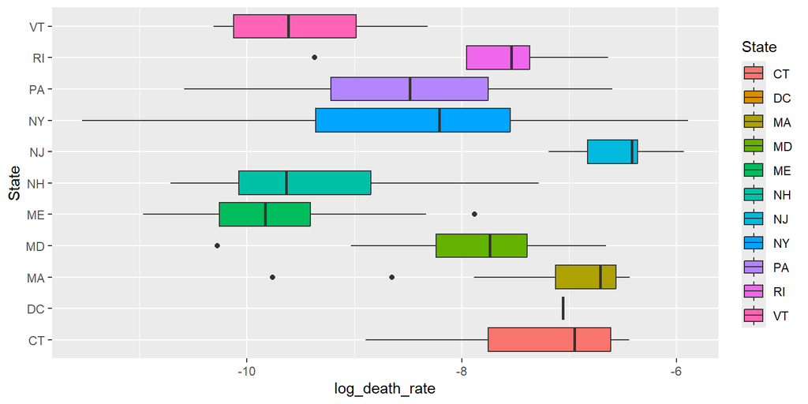

```r
ggplot(covid_county, aes(x=State, y=log_death_rate, fill=State)) + geom_boxplot() + coord_flip()
```

# 3. Analyses

There are a number of studies indicating that COVID affected minority groups more. In the following analyses, we focus on the effect of `WhiteNonHispanicPct2010` over `log_death_rate`.

## 3.1 fit1

Run a regression of `log_death_rate` vs. `WhiteNonHispanicPct2010` controlling `State` (without interactions) as `fit1`.

Controlling for State WhiteNonHispanicPct2010 is a significant variable at the .01 level as indicated by Anova() below. The variable has a coefficient of -0.03811, meaning on average when percentage of whites in counties increases by 1 percentage point, log death rate decreases by about -0.03811, controlling for State.

```r
fit1 <- lm(log_death_rate~WhiteNonHispanicPct2010 + State, data=covid_county)
Anova(fit1)
```

```
## Anova Table (Type II tests)
##
## Response: log_death_rate
##                         Sum Sq  Df F value               Pr(>F)
## WhiteNonHispanicPct2010   62.8   1   80.27 < 0.0000000000000002 ***
## State                     67.9  10    8.67      0.0000000000051 ***
## Residuals                179.9 230
## ---
## Signif. codes:  0 '***' 0.001 '**' 0.01 '*' 0.05 '.' 0.1 ' ' 1
```

```r
summary(fit1)
```

```
##
## Call:
## lm(formula = log_death_rate ~ WhiteNonHispanicPct2010 + State,
##     data = covid_county)
##
## Residuals:
##    Min     1Q Median     3Q    Max
## -3.304 -0.569  0.096  0.583  1.939
##
## Coefficients:
##                         Estimate Std. Error t value             Pr(>|t|)
## (Intercept)             -4.24559    0.45774   -9.28 < 0.0000000000000002 ***
## WhiteNonHispanicPct2010 -0.03811    0.00425   -8.96 < 0.0000000000000002 ***
## StateDC                 -1.48470    0.95640   -1.55              0.12195
## StateMA                  0.16112    0.39207    0.41              0.68149
## StateMD                 -0.98794    0.36286   -2.72              0.00697 **
## StateME                 -1.85768    0.38943   -4.77            0.0000033 ***
## StateNH                 -1.52885    0.42472   -3.60              0.00039 ***
## StateNJ                  0.22725    0.37189    0.61              0.54176
## StateNY                 -0.92669    0.33275   -2.78              0.00580 **
## StatePA                 -0.83254    0.33431   -2.49              0.01347 *
## StateRI                 -0.23245    0.50532   -0.46              0.64595
## StateVT                 -1.65230    0.39825   -4.15            0.0000470 ***
## ---
## Signif. codes:  0 '***' 0.001 '**' 0.01 '*' 0.05 '.' 0.1 ' ' 1
##
## Residual standard error: 0.884 on 230 degrees of freedom
## Multiple R-squared:  0.564,  Adjusted R-squared:  0.543
## F-statistic:   27 on 11 and 230 DF,  p-value: <0.0000000000000002
```

## 3.2 fit.final

a final parsimonious model to identify a set of important variables that are related to `log_death_rate` using first LASSO then backward elimination.

Using LASSO to pick up a few variables in addition to `State`.

The variables selected are: StateDC, StateMA, StateMD, StateME, StateNH, StateNJ, StateNY, StatePA, StateRI, StateVT, PctEmpFIRE, ForeignBornPct, TotalPopEst2019, WhiteNonHispanicPct2010, UrbanInfluenceCode2013.

```r
Y <- covid_county$log_death_rate
X <- model.matrix(log_death_rate~., data=covid_county)[, -1]

##X <- model.matrix(log_death_rate~., data=covid_county_sub)
##colnames(X) dim(X) dim(covid_county_sub$log_death_rate) X
```

```r
# create index needed to force in state vars
colx <- colnames(X)
state_index <- c(rep(1, length(colx)))

# we mark State variables with 0s and other variables with 1s
for (i in 1:length(colx)) {
  if (startsWith(colx[i], "State")) {
    state_index[i] <- 0
  }
}

#check sum(state_index) length(colnames(X))
```

```r
# force in state
set.seed(1)
fit.force.cv <- cv.glmnet(X, Y, alpha=1, nfolds=12, intercept = T,
                       penalty.factor = state_index)
```

```r
coef.1se <- coef(fit.force.cv, s="lambda.1se")
coef.1se <- coef.1se[which(coef.1se !=0),]
coef.1se
```

```
##             (Intercept)                 StateDC                 StateMA
##            -7.666033305            -0.085859161             0.174773118
##                 StateMD                 StateME                 StateNH
##            -0.425740019            -1.859385122            -1.630210486
##                 StateNJ                 StateNY                 StatePA
##             0.673511037            -0.786067307            -0.795374375
##                 StateRI                 StateVT              PctEmpFIRE
##            -0.354212202            -1.550428839             0.062657098
##          ForeignBornPct         TotalPopEst2019 WhiteNonHispanicPct2010
##             0.001887308             0.000000578            -0.003280650
##  UrbanInfluenceCode2013
##            -0.046248109
```

```r
var.1se <- rownames(as.matrix(coef.1se))[-1]

lm.input <- as.formula(paste("log_death_rate", "~", paste(var.1se, collapse = "+")))
lm.input
```

```
## log_death_rate ~ StateDC + StateMA + StateMD + StateME + StateNH +
##     StateNJ + StateNY + StatePA + StateRI + StateVT + PctEmpFIRE +
##     ForeignBornPct + TotalPopEst2019 + WhiteNonHispanicPct2010 +
##     UrbanInfluenceCode2013
```

The plot below indicates that lambda.1se is reasonable to have a small testing error. The MSE is just above .7 which is not too far away from the minimum mse which is just below .7.

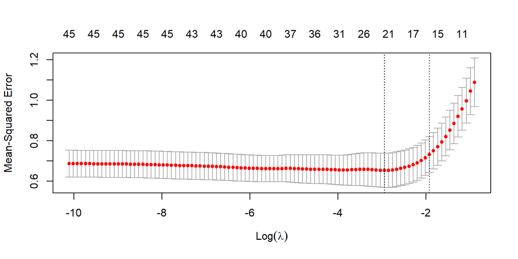

```r
#produce plot of test MSE by lambda value
plot(fit.force.cv)
```

```r
best_lambda <- fit.force.cv$lambda.min
```

We start with set of variables obtained from lasso. The steps are listed below.

1.) ForeignBornPct has highest p value of 0.70778 so we remove that variable first. 2.) TotalPopEst2019 next has a p-value of 0.05488 so we remove that next. 3.) The final fit using this method is State + PctEmpFIRE + WhiteNonHispanicPct2010 + UrbanInfluenceCode2013, all of which has a p-value of less than our .01 threshold.

See steps below.

```r
fit.backward.1 <- lm(log_death_rate ~ State + PctEmpFIRE +
    ForeignBornPct + TotalPopEst2019 + WhiteNonHispanicPct2010 +
    UrbanInfluenceCode2013, data = covid_county)

summary(fit.backward.1)
```

```
##
## Call:
## lm(formula = log_death_rate ~ State + PctEmpFIRE + ForeignBornPct +
##     TotalPopEst2019 + WhiteNonHispanicPct2010 + UrbanInfluenceCode2013,
##     data = covid_county)
##
## Residuals:
##     Min      1Q  Median      3Q     Max
## -3.0871 -0.3898 -0.0088  0.5097  1.9012
##
## Coefficients:
##                             Estimate   Std. Error t value             Pr(>|t|)
## (Intercept)             -6.981939798  0.734066980   -9.51 < 0.0000000000000002
## StateDC                 -0.582850100  0.865086621   -0.67              0.50116
## StateMA                  0.336050812  0.350716316    0.96              0.33899
## StateMD                 -0.395719729  0.334932869   -1.18              0.23865
## StateME                 -1.267405330  0.352213472   -3.60              0.00039
## StateNH                 -1.167027123  0.377604429   -3.09              0.00225
## StateNJ                  0.459158309  0.336529277    1.36              0.17380
## StateNY                 -0.515090681  0.301005305   -1.71              0.08841
## StatePA                 -0.369988863  0.303970048   -1.22              0.22480
## StateRI                 -0.269050468  0.447959215   -0.60              0.54870
## StateVT                 -0.887399320  0.366238571   -2.42              0.01618
## PctEmpFIRE               0.119219327  0.034596680    3.45              0.00068
## ForeignBornPct           0.005947092  0.015845506    0.38              0.70778
## TotalPopEst2019          0.000000412  0.000000247    1.67              0.09633
## WhiteNonHispanicPct2010 -0.016074487  0.007133750   -2.25              0.02520
## UrbanInfluenceCode2013  -0.106088087  0.024902943   -4.26              0.00003
##
## (Intercept)             ***
## StateDC
## StateMA
## StateMD
## StateME                 ***
## StateNH                 **
## StateNJ
## StateNY                 .
## StatePA
## StateRI
## StateVT                 *
## PctEmpFIRE              ***
## ForeignBornPct
## TotalPopEst2019         .
## WhiteNonHispanicPct2010 *
## UrbanInfluenceCode2013  ***
## ---
## Signif. codes:  0 '***' 0.001 '**' 0.01 '*' 0.05 '.' 0.1 ' ' 1
##
## Residual standard error: 0.777 on 226 degrees of freedom
## Multiple R-squared:  0.669,  Adjusted R-squared:  0.647
## F-statistic: 30.4 on 15 and 226 DF,  p-value: <0.0000000000000002
```

```r
fit.backward.2 <- lm(log_death_rate ~ State + PctEmpFIRE +
    TotalPopEst2019 + WhiteNonHispanicPct2010 +
    UrbanInfluenceCode2013, data = covid_county)

summary(fit.backward.2)
```

```
##
## Call:
## lm(formula = log_death_rate ~ State + PctEmpFIRE + TotalPopEst2019 +
##     WhiteNonHispanicPct2010 + UrbanInfluenceCode2013, data = covid_county)
##
## Residuals:
##     Min      1Q  Median      3Q     Max
## -3.0470 -0.3944 -0.0055  0.5098  1.9077
##
## Coefficients:
##                             Estimate   Std. Error t value             Pr(>|t|)
## (Intercept)             -6.832593126  0.615689031  -11.10 < 0.0000000000000002
## StateDC                 -0.640319912  0.849814368   -0.75              0.45194
## StateMA                  0.353190584  0.347071727    1.02              0.30994
## StateMD                 -0.410547669  0.331964606   -1.24              0.21747
## StateME                 -1.265745502  0.351518608   -3.60              0.00039
## StateNH                 -1.160398708  0.376476735   -3.08              0.00231
## StateNJ                  0.478871338  0.331775576    1.44              0.15030
## StateNY                 -0.509803802  0.300105987   -1.70              0.09074
## StatePA                 -0.374355463  0.303171965   -1.23              0.21818
## StateRI                 -0.252880160  0.445037915   -0.57              0.57045
## StateVT                 -0.877546863  0.364604626   -2.41              0.01689
## PctEmpFIRE               0.123228932  0.032843577    3.75              0.00022
## TotalPopEst2019          0.000000445  0.000000230    1.93              0.05488
## WhiteNonHispanicPct2010 -0.017778675  0.005491650   -3.24              0.00139
## UrbanInfluenceCode2013  -0.105031931  0.024696570   -4.25             0.000031
##
## (Intercept)             ***
## StateDC
## StateMA
## StateMD
## StateME                 ***
## StateNH                 **
## StateNJ
## StateNY                 .
## StatePA
## StateRI
## StateVT                 *
## PctEmpFIRE              ***
## TotalPopEst2019         .
## WhiteNonHispanicPct2010 **
## UrbanInfluenceCode2013  ***
## ---
## Signif. codes:  0 '***' 0.001 '**' 0.01 '*' 0.05 '.' 0.1 ' ' 1
##
## Residual standard error: 0.776 on 227 degrees of freedom
## Multiple R-squared:  0.669,  Adjusted R-squared:  0.648
## F-statistic: 32.7 on 14 and 227 DF,  p-value: <0.0000000000000002
```

```r
fit.backward.3 <- lm(log_death_rate ~ State + PctEmpFIRE +
    WhiteNonHispanicPct2010 +
    UrbanInfluenceCode2013, data = covid_county)

summary(fit.backward.3)
```

```
##
## Call:
## lm(formula = log_death_rate ~ State + PctEmpFIRE + WhiteNonHispanicPct2010 +
##     UrbanInfluenceCode2013, data = covid_county)
##
## Residuals:
##     Min      1Q  Median      3Q     Max
## -3.1252 -0.4175  0.0023  0.4914  1.9353
##
## Coefficients:
##                         Estimate Std. Error t value             Pr(>|t|)
## (Intercept)              -6.2509     0.5400  -11.57 < 0.0000000000000002 ***
## StateDC                  -0.8119     0.8502   -0.95              0.34062
## StateMA                   0.4193     0.3474    1.21              0.22870
## StateMD                  -0.4996     0.3307   -1.51              0.13221
## StateME                  -1.2176     0.3527   -3.45              0.00066 ***
## StateNH                  -1.1192     0.3781   -2.96              0.00340 **
## StateNJ                   0.3743     0.3293    1.14              0.25685
## StateNY                  -0.4707     0.3012   -1.56              0.11948
## StatePA                  -0.3231     0.3038   -1.06              0.28872
## StateRI                  -0.2838     0.4474   -0.63              0.52650
## StateVT                  -0.8234     0.3657   -2.25              0.02530 *
## PctEmpFIRE                0.1466     0.0307    4.77         0.0000032232 ***
## WhiteNonHispanicPct2010  -0.0249     0.0041   -6.07         0.0000000054 ***
## UrbanInfluenceCode2013   -0.1111     0.0246   -4.51         0.0000105057 ***
## ---
## Signif. codes:  0 '***' 0.001 '**' 0.01 '*' 0.05 '.' 0.1 ' ' 1
##
## Residual standard error: 0.78 on 228 degrees of freedom
## Multiple R-squared:  0.663,  Adjusted R-squared:  0.644
## F-statistic: 34.5 on 13 and 228 DF,  p-value: <0.0000000000000002
```

Running a final model `fit.final` of `log_death_rate` vs the set of variables from backward elimination (Q4.iii). Also include `WhiteNonHispanicPct2010` regardless since we know the death rate among the elderly is higher. Report the summary of `fit.final`.

Some states have positive coefficients whereas others negative, which means that some states such as NJ have higher death rates (positive coefficents) compared to others with negative coeffs (such as NY. The three non-state variables included are PctEmpFRE, WhiteNonHispanicPct2010, and UrbanInfluenceCode2013.

```r
fit.final <- lm(log_death_rate ~ State + PctEmpFIRE +
    WhiteNonHispanicPct2010 +
    UrbanInfluenceCode2013, data = covid_county)

summary(fit.final)
```

```
##
## Call:
## lm(formula = log_death_rate ~ State + PctEmpFIRE + WhiteNonHispanicPct2010 +
##     UrbanInfluenceCode2013, data = covid_county)
##
## Residuals:
##     Min      1Q  Median      3Q     Max
## -3.1252 -0.4175  0.0023  0.4914  1.9353
##
## Coefficients:
##                         Estimate Std. Error t value             Pr(>|t|)
## (Intercept)              -6.2509     0.5400  -11.57 < 0.0000000000000002 ***
## StateDC                  -0.8119     0.8502   -0.95              0.34062
## StateMA                   0.4193     0.3474    1.21              0.22870
## StateMD                  -0.4996     0.3307   -1.51              0.13221
## StateME                  -1.2176     0.3527   -3.45              0.00066 ***
## StateNH                  -1.1192     0.3781   -2.96              0.00340 **
## StateNJ                   0.3743     0.3293    1.14              0.25685
## StateNY                  -0.4707     0.3012   -1.56              0.11948
## StatePA                  -0.3231     0.3038   -1.06              0.28872
## StateRI                  -0.2838     0.4474   -0.63              0.52650
## StateVT                  -0.8234     0.3657   -2.25              0.02530 *
## PctEmpFIRE                0.1466     0.0307    4.77         0.0000032232 ***
## WhiteNonHispanicPct2010  -0.0249     0.0041   -6.07         0.0000000054 ***
## UrbanInfluenceCode2013   -0.1111     0.0246   -4.51         0.0000105057 ***
## ---
## Signif. codes:  0 '***' 0.001 '**' 0.01 '*' 0.05 '.' 0.1 ' ' 1
##
## Residual standard error: 0.78 on 228 degrees of freedom
## Multiple R-squared:  0.663,  Adjusted R-squared:  0.644
## F-statistic: 34.5 on 13 and 228 DF,  p-value: <0.0000000000000002
```

`WhiteNonHispanicPct2010` significant at .01 level controlling for all other variables in `fit.final`, as indicated by p-value of well below .01.

```r
Anova(fit.final)
```

```
## Anova Table (Type II tests)
##
## Response: log_death_rate
##                         Sum Sq  Df F value       Pr(>F)
## State                     35.3  10     5.8 0.0000000901 ***
## PctEmpFIRE                13.9   1    22.8 0.0000032232 ***
## WhiteNonHispanicPct2010   22.4   1    36.8 0.0000000054 ***
## UrbanInfluenceCode2013    12.4   1    20.3 0.0000105057 ***
## Residuals                138.9 228
## ---
## Signif. codes:  0 '***' 0.001 '**' 0.01 '*' 0.05 '.' 0.1 ' ' 1
```

State is significant at .01 level controlling for all others as indicated by its p-value by Anova() below. Controlling for other variables, the State of Massachusetts (MA) has the largest log_death_rate as indicated below with a coefficient of -5.8315.

```r
Anova(fit.final)
```

```
## Anova Table (Type II tests)
##
## Response: log_death_rate
##                         Sum Sq  Df F value       Pr(>F)
## State                     35.3  10     5.8 0.0000000901 ***
## PctEmpFIRE                13.9   1    22.8 0.0000032232 ***
## WhiteNonHispanicPct2010   22.4   1    36.8 0.0000000054 ***
## UrbanInfluenceCode2013    12.4   1    20.3 0.0000105057 ***
## Residuals                138.9 228
## ---
## Signif. codes:  0 '***' 0.001 '**' 0.01 '*' 0.05 '.' 0.1 ' ' 1
```

```r
fit.final.nointercept <- (lm(log_death_rate ~  0 + State + PctEmpFIRE +
    WhiteNonHispanicPct2010 +
    UrbanInfluenceCode2013, data = covid_county))
```

```r
finalcoef <- as.data.frame(fit.final.nointercept$coefficients)

finalcoef <- tibble::rownames_to_column(finalcoef, "term")
arrange(finalcoef, desc(fit.final.nointercept$coefficients))
```

```
##                       term fit.final.nointercept$coefficients
## 1               PctEmpFIRE                             0.1466
## 2  WhiteNonHispanicPct2010                            -0.0249
## 3   UrbanInfluenceCode2013                            -0.1111
## 4                  StateMA                            -5.8315
## 5                  StateNJ                            -5.8766
## 6                  StateCT                            -6.2509
## 7                  StateRI                            -6.5347
## 8                  StatePA                            -6.5739
## 9                  StateNY                            -6.7216
## 10                 StateMD                            -6.7505
## 11                 StateDC                            -7.0628
## 12                 StateVT                            -7.0743
## 13                 StateNH                            -7.3701
## 14                 StateME                            -7.4684
```

It seems that the linear model assumptions are reasonably met. The residuals graph shows that linearity assumption is met, and while there may be an indication of some heteroscedacity it is not too eminent. The qqplot suggests that normality assumption is also met, as indicated by most observations falling on or close to the diagonal line.

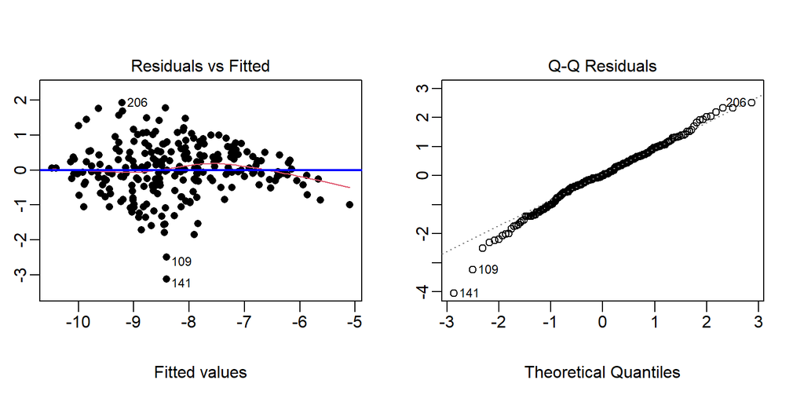

```r
par(mfrow=c(1,2), mar=c(5,2,4,2), mgp=c(3,0.5,0)) # plot(fit3) produces several plots
plot(fit.final, 1, pch=16) # residual plot
abline(h=0, col="blue", lwd=2)
plot(fit.final, 2) # qqplot
```